# The Effect of Childcare Hours on Suggested Child Tax Benefits

Author

DACSS 603 Final Project

## Literature Review

For many families across the world, the Covid-19 pandemic resulted in sudden lifestyle changes and increased levels of stress. Although every family was impacted by the pandemic in some way, certain demographics were more impacted by these lifestyle changes than others. The economic impact of the Covid-19 pandemic was greatest on women, Black people, Latinos, and low-income families (Chen, Byrne, and Vélez 2022). Women were reported to have more childcare responsibilities than men during the pandemic regardless of their employment status, and these responsibilities have led to increased levels of stress (Zamarro and Prados 2021). During the Covid-19 pandemic, Mothers of elementary school-aged children reported significantly higher levels of stress than mothers of older children and women without children, while there were no significant differences in stress levels between fathers and men without children (Zamarro and Prados 2021). The results of a study by Chen, Byrne, and Vélez (2022) showed that low-income families faced more financial hardships than higher income families, and that Black and Latino families faced more financial hardships than White families. Low-income, Black, and Latino families were more affected by layoffs and reduced pay compared to higher income White families, and they were also less likely to work from home, making them more likely to be exposed to Covid-19.

In order to provide financial support to families during the pandemic, the Child Tax Credit was expanded as part of the American Rescue Plan Act of 2021 (“American Rescue Plan” 2021). The Child Tax Credit increased from $2,000 per child to $3,000 per child for children over the age of six and $3,600 for children under the age of six. The age limit for the Child Tax Credit also increased from 16 to 17 years old (“American Rescue Plan” 2021).

There is evidence that a larger Child Tax Credit payments could greatly reduce levels of household poverty and child poverty in the United States, which would have a positive effect on the wellbeing of American families with children (Pressman and Scott III 2022). Research by Batra, Jackson, and Hamad (2023) examined the effects of the expanded Child Tax Credit on the mental health of low-income adults with children under the age of 18, and the results showed that low-income adults reported having fewer anxiety and depressive symptoms after the expansion of the Child Tax Credit. Black and Hispanic respondents had a larger decrease in anxiety symptoms than White adults, which could be because Black and Hispanic families reported higher rates of job loss than White families during the Covid-19 pandemic (Batra, Jackson, and Hamad 2023). Black adolescents have also reported having significantly lower depressive symptoms after the expanded Child Tax Credit, along with publicly insured adolescents in research by Chavez et al. (2024).

Despite the benefits of an extended Child Tax Credit, not all Americans are in support of it. Previous research by López-Santana, Núñez, and Béland (2023) shows that while a majority of Americans support the Child Tax Credit, fewer Americans are in favor of the Child Tax Credit than there are for other social programs, like the Supplemental Nutrition Assistance Program (SNAP). This study also showed that Americans may view families with children and low-income families as less deserving of government support than other demographics, like older people and disabled people (López-Santana, Núñez, and Béland 2023). There is also evidence that support for the Child Tax Credit varies between demographics. According to the results of the study by López-Santana, Núñez, and Béland (2023), Democrats are more supportive of the Child Tax Credit than Republicans, and Black people are more supportive of the Child Tax Credit than White people. People with children under the age of 17 were observed to have higher levels of support for the Child tax Credit, which could be because they directly benefit from it (López-Santana, Núñez, and Béland 2023).

## Research Question

My research question is: Are people who spend more time caring for their children on their own more likely to support a higher child tax credit?

There are studies focusing on which demographics have benefited from the 2021 extended Child Tax Credit, but there does not seem to be much research measuring public support for an increased Child Tax Credit. According to the results of the study by López-Santana, Núñez, and Béland (2023), people of certain demographics are more likely to support the Child Tax Credit than others, with Democrats showing more support than Republicans and Black people showing more support than White people. Parents with children under 17 years old were also reported to have more support for the Child Tax Credit, showing that the characteristics of one’s family can influence their support of the Child Tax Credit and other policies.

This research question could help further the knowledge of how family dynamics can shape support for policies like the Child Tax Credit. This knowledge could also help identify if certain types of families are in need of the additional financial support from an increased Child Tax Benefit. If certain demographics, such as parents who spend a lot of time caring for their children on their own, support an increased Child Tax Benefit, that could be a sign that they are currently not receiving enough financial support.

## Hypothesis

My hypothesis is that people who spend more time caring for their children on their own are more likely to support a higher child tax credit.

This is my hypothesis because parents who spend more time caring for their children on their own may be more aware of the financial impact of caring for children, and they may be in more need of additional support.

Parents with children ages 17 and under were more likely to support the extended 2021 Child Tax Credit, most likely because their children were in the eligible age range (López-Santana, Núñez, and Béland 2023). People who directly benefit from a policy may be more supportive of it, and parents who spend less time caring for their children may see an increased Child Tax Credit as less beneficial compared to parents who solely care for their children most of the time.

It is not known if parents who spend more time caring for their children are more likely to support a higher Child Tax Credit, but there is evidence that parents who spent more time caring for their children during the pandemic experienced higher levels of stress. Women spent more time caring for their children than men did during the Covid-19 pandemic, and mothers with elementary school age children reported higher levels of stress than parents with older children (Chen, Byrne, and Vélez 2022; Zamarro and Prados 2021). Parents who spend less time caring for their children may be less aware of the costs of caring for children, and as a result they will not see a need for increased Child Tax Credit.

## Dataset

The data I am using for this experiment is data from the 2021 American Family Survey (AFS) conducted by The Center for the Study of Elections and Democracy at Brigham Young University and YouGov (https://csed.byu.edu/american-family-survey). This survey has been conducted each year since 2015, and it investigates the family structures, experiences, and political opinions of families living in the United States. The sample for this survey is 3,000 adults living in the United States who were selected from an initial group of 3,201 respondents using stratified sampling from the full 2019 American Community Survey 1-year sample.

I came across this dataset while looking at different social surveys on the Harvard Dataverse, and I thought the questions in the AFS relating to opinions on social policies were interesting.

```r
library(haven)
library(tidyverse)
library(dplyr)
library(dagitty)
library(skimr)
library(modelsummary)
library(kableExtra)
```

```r
afs_full <- read_dta("afs2021.dta")
head(afs_full)
```

```
# A tibble: 6 × 413
      caseid weight PAR006_treat           FAMTAX007_treat s21_MSC001 s21_MSC003
       <dbl>  <dbl> <dbl+lbl>              <dbl+lbl>       <dbl+lbl>  <dbl+lbl>
1 1492039695  0.698 1 [Show rows: The cor… 2 [Treatment 1… 5 [Not cu… NA
2 1492042119  1.20  1 [Show rows: The cor… 3 [Treatment 2… 5 [Not cu… NA
3 1492870805  1.16  1 [Show rows: The cor… 1 [Control]     1 [Marrie… 19 [7 yea…
4 1492850287  0.771 2 [No extra rows on P… 3 [Treatment 2… 5 [Not cu… NA
5 1492863669  0.810 2 [No extra rows on P… 2 [Treatment 1… 4 [Curren… NA
6 1492850239  0.857 1 [Show rows: The cor… 1 [Control]     5 [Not cu… NA
# ℹ 407 more variables: s21_MSC003_b_1 <dbl+lbl>, s21_MSC003_b_2 <dbl+lbl>,
#   s21_MSC003_b_3 <dbl+lbl>, s21_MSC003_c <dbl+lbl>, s21_MSC004 <dbl+lbl>,
#   s21_MSC005 <dbl+lbl>, s21_MSC011 <dbl+lbl>, s21_MSC012 <dbl+lbl>,
#   s21_MSC012_b <dbl+lbl>, s21_MSC010 <dbl+lbl>, s21_MSC013 <dbl+lbl>,
#   s21_MSC014_age_child1 <dbl+lbl>, s21_MSC014_home_child1 <dbl+lbl>,
#   s21_MSC014_bio_child1 <dbl+lbl>, s21_MSC014_gender_child1 <dbl+lbl>,
#   s21_MSC014_age_child2 <dbl+lbl>, s21_MSC014_home_child2 <dbl+lbl>, …
```

```r
dim(afs_full)
```

```
[1] 3000  413
```

The full AFS 2021 dataset has 3,000 rows and 413 columns.

I do not need all of these variables for this project, so I am going to create a new dataset with a smaller selection of variables relevant to the research question.

## Data Preprocessing

```r
afs <- afs_full[c("s21_MSC013", "birthyr", "s21_DEM015", "gender", "race",
                  "ideo5", "faminc_new", "Pick5to18Child_age",
                  "s21_FAMTAX003_rule", "s21_PID001", "s21_COV023_4_1",
                  "s21_MSC014_c")]
```

I selected 12 variables from the full dataset, but the names of several of these variables are not indicative of what they represent, so I will rename them to make things more clear.

```r
afs <- afs |>
  rename("number_children" = "s21_MSC013",
         "childcare_hours" = "s21_DEM015",
         "percent_care_self" = "s21_COV023_4_1",
         "PID" = "s21_PID001",
         "child_benefit" = "s21_FAMTAX003_rule",
         "child_age" = "Pick5to18Child_age",
         "number_household" = "s21_MSC014_c")
```

After renaming the variables, I am recoding values for the categorical variables. I am also recoding values for child_age to be numeric instead of strings, so it can be continuous.

```r
afs <- afs |>
  mutate(
    gender = case_when(
      gender == 1 ~ "male",
      gender == 2 ~ "female"),
    PID = case_when(
      PID == 1 ~ "Republican",
      PID == 2 ~ "Democrat",
      PID == 3 ~ "Independent",
      PID == 4 ~ "Other"
      ),
    ideo5 = case_when(
      ideo5 == 1 | ideo5 == 2 ~ "Liberal",
      ideo5 == 3 ~ "Moderate",
      ideo5 == 4 | ideo5 == 5 ~ "Conservative",
      ideo5 == 6 ~ "Not Sure"
    ),
    faminc_new = case_when(
      faminc_new >= 1 & faminc_new <= 4  ~ "less than $40,000",
      faminc_new >= 5 & faminc_new <= 8  ~ "$40,000 to $79,999",
      faminc_new >= 9 & faminc_new <= 12  ~ "$80,000 to $199,999",
      faminc_new >= 13 & faminc_new <= 16  ~ "$200,000 or more",
      faminc_new == 97 ~ NA
    ),
    race = case_when(
      race == 1 ~ "White",
      race == 2 ~ "Black",
      race == 3 ~ "Hispanic",
      race == 4 ~ "Asian",
      race == 5 ~ "Native American",
      race == 6 ~ "Two or more races",
      race == 7 ~ "Other",
      race == 8 ~ "Middle Eastern"
    ),
    child_age = case_when(
      child_age == "5-year-old" ~ 5,
      child_age == "6-year-old" ~ 6,
      child_age == "7-year-old" ~ 7,
      child_age == "8-year-old" ~ 8,
      child_age == "9-year-old" ~ 9,
      child_age == "10-year-old" ~ 10,
      child_age == "11-year-old" ~ 11,
      child_age == "12-year-old" ~ 12,
      child_age == "13-year-old" ~ 13,
      child_age == "14-year-old" ~ 14,
      child_age == "15-year-old" ~ 15,
      child_age == "16-year-old" ~ 16,
      child_age == "17-year-old" ~ 17,
      child_age == "18-year-old" ~ 18,
      child_age == "" ~ NA
    )
    )
```

The values in the column child_benefit are measured in hundreds of dollars, so I am adding a new column child_benefit_dollars to represent the amount of money in dollars by multiplying the values in child_benefit by 100.

The column number_children uses the value 99 to represent having no children, so I recoded observations where number_children is 99 to be 0.

```r
#column for tax benefit amount in dollars
afs$child_benefit_dollars <- afs$child_benefit * 100

#convert 99 to 0 for number of children
afs$number_children[afs$number_children == 99] <- 0
```

## Descriptive Statistics

This new dataset has 3,000 rows and 13 columns.

```r
dim(afs)
```

```
[1] 3000   13
```

```r
head(afs)
```

```
# A tibble: 6 × 13
  number_children birthyr childcare_hours gender race  ideo5        faminc_new
  <dbl+lbl>         <dbl> <dbl+lbl>       <chr>  <chr> <chr>        <chr>
1 0                  1960 NA              male   White Liberal      less than $…
2 2 [2]              1965 NA              male   White Conservative $80,000 to …
3 0                  1966 NA              male   White Moderate     $40,000 to …
4 0                  1958 NA              female White Moderate     $40,000 to …
5 2 [2]              1971 NA              female White Conservative <NA>
6 0                  1976 NA              male   White Moderate     $40,000 to …
# ℹ 6 more variables: child_age <dbl>, child_benefit <dbl+lbl>, PID <chr>,
#   percent_care_self <dbl+lbl>, number_household <dbl+lbl>,
#   child_benefit_dollars <dbl>
```

Now that the data has been preprocessed, a summary of the data can be viewed.

```r
summary(afs)
```

```
 number_children     birthyr     childcare_hours    gender
 Min.   : 0.000   Min.   :1927   Min.   : 0.00   Length:3000
 1st Qu.: 0.000   1st Qu.:1958   1st Qu.: 3.00   Class :character
 Median : 1.000   Median :1972   Median :10.00   Mode  :character
 Mean   : 1.455   Mean   :1972   Mean   :11.81
 3rd Qu.: 2.000   3rd Qu.:1986   3rd Qu.:24.00
 Max.   :14.000   Max.   :2003   Max.   :24.00
                                 NA's   :2444
     race              ideo5            faminc_new          child_age
 Length:3000        Length:3000        Length:3000        Min.   : 5.00
 Class :character   Class :character   Class :character   1st Qu.: 9.00
 Mode  :character   Mode  :character   Mode  :character   Median :13.00
                                                          Mean   :12.23
                                                          3rd Qu.:16.00
                                                          Max.   :18.00
                                                          NA's   :2467
 child_benefit       PID            percent_care_self number_household
 Min.   : 0.00   Length:3000        Min.   :  0.00    Min.   :1.000
 1st Qu.: 3.00   Class :character   1st Qu.: 50.00    1st Qu.:2.000
 Median :24.00   Mode  :character   Median : 50.00    Median :2.000
 Mean   :24.14                      Mean   : 59.35    Mean   :2.632
 3rd Qu.:38.00                      3rd Qu.: 90.00    3rd Qu.:3.000
 Max.   :60.00                      Max.   :100.00    Max.   :9.000
 NA's   :4                          NA's   :2519
 child_benefit_dollars
 Min.   :   0
 1st Qu.: 300
 Median :2400
 Mean   :2414
 3rd Qu.:3800
 Max.   :6000
 NA's   :4
```

```r
glimpse(afs)
```

```
Rows: 3,000
Columns: 13
$ number_children       <dbl+lbl> 0, 2, 0, 0, 2, 0, 0, 2, 1, 4, 0, 0, 1, 3, 0,…
$ birthyr               <dbl> 1960, 1965, 1966, 1958, 1971, 1976, 1954, 1947, …
$ childcare_hours       <dbl+lbl> NA, NA, NA, NA, NA, NA, NA, NA, 24, NA, NA, …
$ gender                <chr> "male", "male", "male", "female", "female", "mal…
$ race                  <chr> "White", "White", "White", "White", "White", "Wh…
$ ideo5                 <chr> "Liberal", "Conservative", "Moderate", "Moderate…
$ faminc_new            <chr> "less than $40,000", "$80,000 to $199,999", "$40…
$ child_age             <dbl> NA, NA, NA, NA, NA, NA, NA, NA, NA, NA, NA, NA, …
$ child_benefit         <dbl+lbl> 36,  1, 20, 60,  9,  0,  0,  0, 29,  0,  1, …
$ PID                   <chr> "Democrat", "Independent", "Republican", "Democr…
$ percent_care_self     <dbl+lbl>  NA,  NA,  NA,  NA,  NA,  NA,  NA,  NA, 100,…
$ number_household      <dbl+lbl> 1, 2, 2, 1, 1, 2, 2, 4, 3, 3, 2, 2, 1, 3, 2,…
$ child_benefit_dollars <dbl> 3600, 100, 2000, 6000, 900, 0, 0, 0, 2900, 0, 10…
```

Several variables in this dataset have large numbers of NA variables, which means that a majority of the 3,000 rows in the dataset will not be included in the analysis using the regression model. All of these variables relate to caring for children, so participants without children did not have responses for the related questions.

```r
sum(is.na(afs$childcare_hours))
```

```
[1] 2444
```

```r
sum(is.na(afs$percent_care_self))
```

```
[1] 2519
```

```r
sum(is.na(afs$child_age))
```

```
[1] 2467
```

The most important variables for my research question are **child_benefit** and **childcare_hours**. Both child_benefit and childcare_hours are continuous variables.

The variable child_benefit represents responses to the question, “Suppose that a policy of permanent government payments to parents was passed by Congress. How large do you think the annual benefit should be for each child?” The responses to this question are in hundreds of dollars and range from 0 to 60, meaning that the smallest suggested amount is $0, and the largest is $6,000. The median suggested amount is $2400, and the mean suggested amount is $2414.

I made the alternative column **child_benefit_dollars**, which multiplies the values in child_benefit by 100 to represent the exact cost of the suggested benefit.

The variable childcare_hours represents responses to the question, “In an average weekday, how many hours are you solely responsible for the care of your children?” The minimum number of hours is 0, and the maximum number of hours is 24. The median number of hours is 10, and the mean number of hours is 11.81.

**Other variables of interest are:**

**number_children** is a continuous variable that represents the number of children the respondent has. The minimum number of children is 0, but all of the observations in the model for this research question will have a number_children value of at least 1. The median number of children is 1, the mean is 1.455, and the maximin is 14.

**child_age** is a continuous variable that represents the age of a child of the respondent. If the respondent has more than one child, the age of one of their children was randomly selected. The children selected for this variable were between the ages 5 and 18.

**gender** is a categorical variable that represents the gender of the respondent. The 2 response options for this variable are “male” and “female” race is a categorical variable that represents the race of the respondent. The 8 response options for this response are “White”, “Black”, “Hispanic”, “Asian”, “Native American”, “Two or more races”, “Other”, and “Middle Eastern”.

**PID** is a categorical variable that represents the political ideology of the respondent. The 4 response options are “Democrat”, “Republican”, “Independent”, and “Other”.

**faminc_new** is a categorical variable that represents the household income of the respondent. In the original dataset there were 17 responses options, but I combined them into 4 categories: “less than $40,000”, “$40,000 to $79,999”, “$80,000 to $199,999”, and “$200,000 or more”.

## Model Fitting/Hypothesis Testing

### DAG

The outcome variable for this model is **child_benefit_dollars**, which is a continuous variable that represents the amount of the respondent’s suggested annual child tax benefit in dollars.

The explanatory variable for this model is **childcare_hours**, which is a continuous variable that represents the number of hours in a day that the respondent is solely responsible for their children.

I created a DAG based on my assumptions about the relationships between variables in this dataset. I believe that the number of hours one spends solely caring for their children will influence the amount of their suggested child tax benefit.

I also believe that the parent’s gender and children’s ages will influence the number of hours one spends solely caring for their children. Gender has an influence on the time parents spend caring for their children, with women spending more time than men. Parents with younger children may spend more time caring for their children than people with older children because older children are more independent. Low-income parents may also spend more time caring for their children because they may have difficulty affording other forms of childcare, such as day care. Parents who have a higher number of children may have more responsibilities, which results in the parents spending more time caring for their children.

Parents with younger children were more likely to support the increased Child Tax Credit because they directly benefit from it, so they may also support a higher annual child tax benefit. Low-income parents would also benefit from an increased child tax benefit, so they may be more supportive of it than higher income families. Parents with more children may also be more likely to support a higher annual child tax benefit because the amount of money increases per child. Race and political identification have also been shown to influence people’s levels of support for the increased Child Tax Credit, so these factors may influence the amount of their suggested tax benefit.

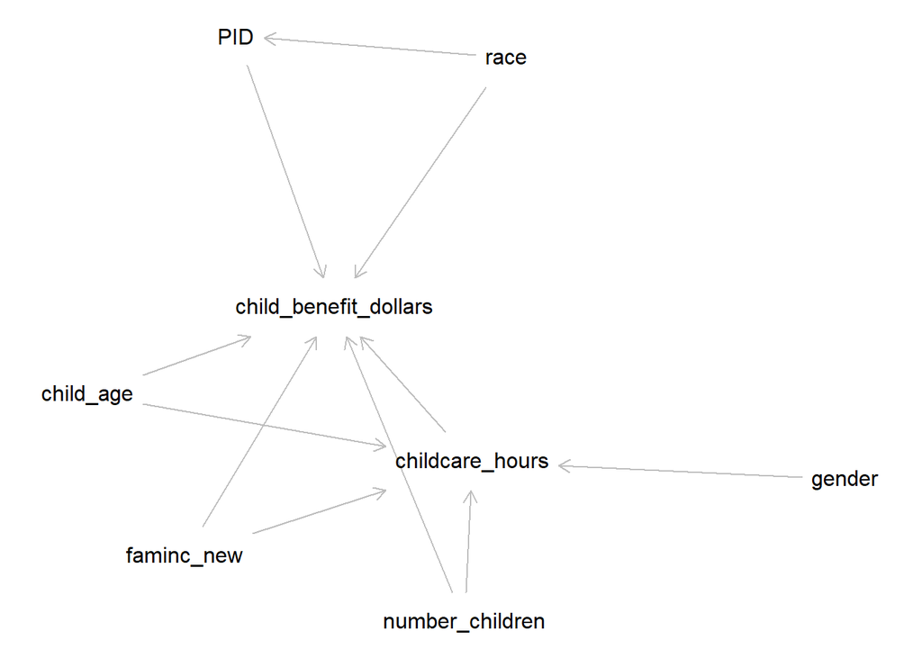

```r
dag <- dagitty("
        dag{
        childcare_hours -> child_benefit_dollars
        PID -> child_benefit_dollars
        race -> PID
        faminc_new -> child_benefit_dollars
        number_children -> child_benefit_dollars
        race -> child_benefit_dollars
        child_age -> child_benefit_dollars
        child_age -> childcare_hours
        faminc_new -> childcare_hours
        number_children -> childcare_hours
        gender -> childcare_hours
        }
        "
        ) |> graphLayout()

dag |> plot()
```

Based on the DAG, the control variables should be child_age, faminc_new, and number_children.

```r
dag |> adjustmentSets(exposure = "childcare_hours",
                      outcome = "child_benefit_dollars")
```

```
{ child_age, faminc_new, number_children }
```

### Multiple Regression Model

```r
mod <- lm(child_benefit_dollars ~ childcare_hours + child_age +
            number_children + faminc_new, data = afs)
summary(mod)
```

```
Call:
lm(formula = child_benefit_dollars ~ childcare_hours + child_age +
    number_children + faminc_new, data = afs)

Residuals:
    Min      1Q  Median      3Q     Max
-3606.7 -1695.8    34.3  1599.6  3331.5

Coefficients:
                              Estimate Std. Error t value Pr(>|t|)
(Intercept)                   3972.040    574.131   6.918 1.73e-11 ***
childcare_hours                 -1.076     11.019  -0.098    0.922
child_age                      -41.386     23.817  -1.738    0.083 .
number_children                 -9.971     62.271  -0.160    0.873
faminc_new$40,000 to $79,999  -245.054    512.385  -0.478    0.633
faminc_new$80,000 to $199,999 -535.808    516.657  -1.037    0.300
faminc_newless than $40,000    -39.848    514.316  -0.077    0.938
---
Signif. codes:  0 '***' 0.001 '**' 0.01 '*' 0.05 '.' 0.1 ' ' 1

Residual standard error: 1988 on 417 degrees of freedom
  (2576 observations deleted due to missingness)
Multiple R-squared:  0.01763,   Adjusted R-squared:  0.003497
F-statistic: 1.247 on 6 and 417 DF,  p-value: 0.2809
```

### Interpretation

The coefficient of the explanatory variable childcare_hours is -1.075937, and the 95% confidence interval is [-22.73656, 20.58469].

This does not support the hypothesis that people who spend more time caring for their children on their own are more likely to support a higher Child Tax Credit.

For every one hour increase in hours that a parent is solely responsible for their children, their recommended amount for an annual child tax benefit decreases by one dollar.

According to this regression model, there is no significant change in the suggested annual child benefit amount based on the number of hours one spends caring for their children on their own.

```r
coefs <- coef(mod)
confints <- confint(mod)

coefs["childcare_hours"]
```

```
childcare_hours
      -1.075937
```

```r
confint(mod, parm = "childcare_hours")
```

```
                    2.5 %   97.5 %
childcare_hours -22.73656 20.58469
```

```r
confints <- confint(mod)

coefs
```

```
                  (Intercept)               childcare_hours
                  3972.040474                     -1.075937
                    child_age               number_children
                   -41.386211                     -9.971035
 faminc_new$40,000 to $79,999 faminc_new$80,000 to $199,999
                  -245.054348                   -535.807893
  faminc_newless than $40,000
                   -39.847933
```

```r
confints
```

```
                                    2.5 %      97.5 %
(Intercept)                    2843.48868 5100.592272
childcare_hours                 -22.73656   20.584690
child_age                       -88.20249    5.430065
number_children                -132.37461  112.432540
faminc_new$40,000 to $79,999  -1252.23319  762.124498
faminc_new$80,000 to $199,999 -1551.38427  479.768484
faminc_newless than $40,000   -1050.82369  971.127827
```

All of the coefficients in this model were negative. According to this model, the suggested child tax benefit decreases by $41.39 for a one-year increase in the child’s age, and it decreases by $9.97 for every child one has. The suggested child tax benefit is higher from families with an income of $200,000 than all of the other income groups, which all make lower than $200,000 annually.

None of the coefficients were statistically significant at the 0.05 level, and they all fall within their 95 percent confidence intervals.

The p-value for child_age is 0.083, so it is significant at the 0.1 level. This is the only significant effect for any of the coefficients.

## Diagnostics and Model Evaluation

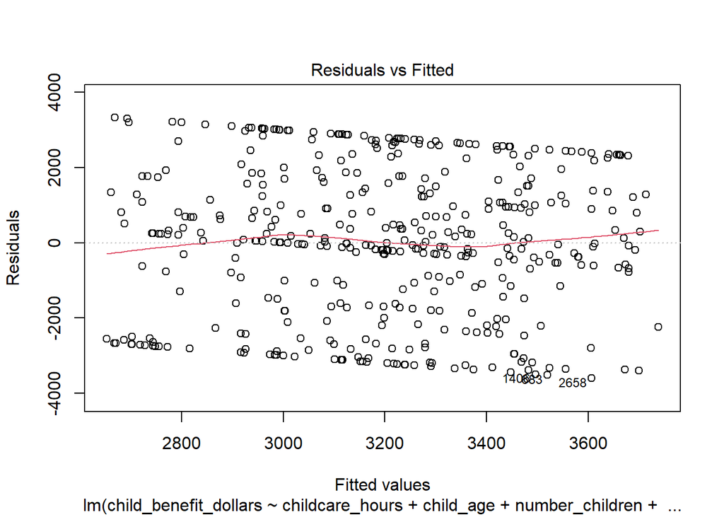

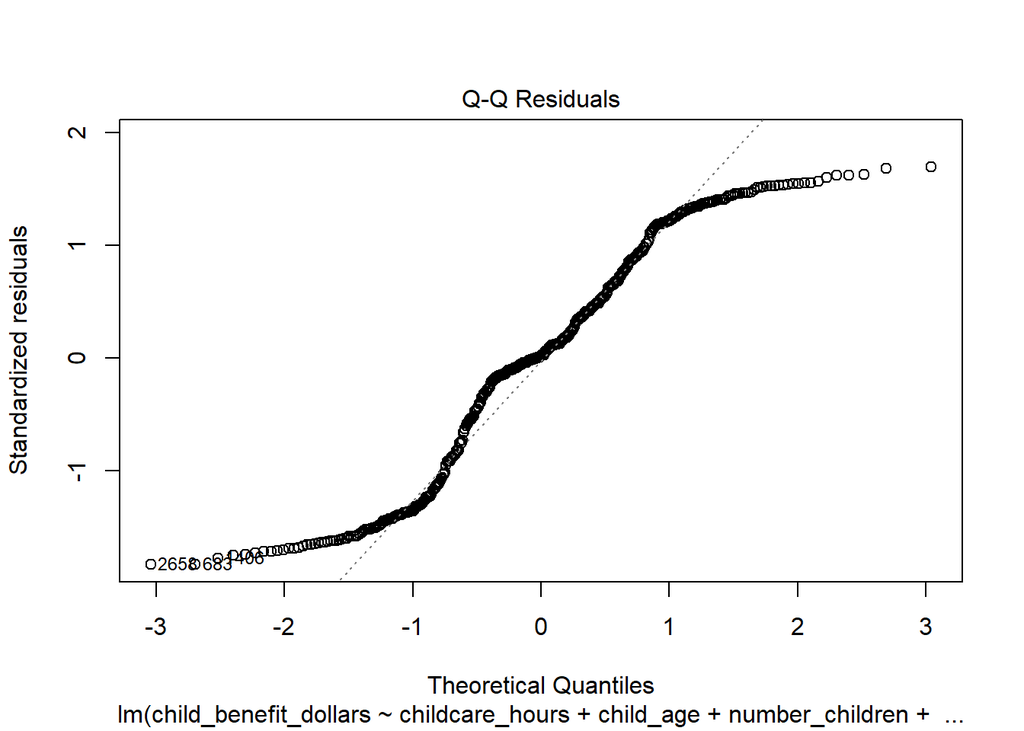

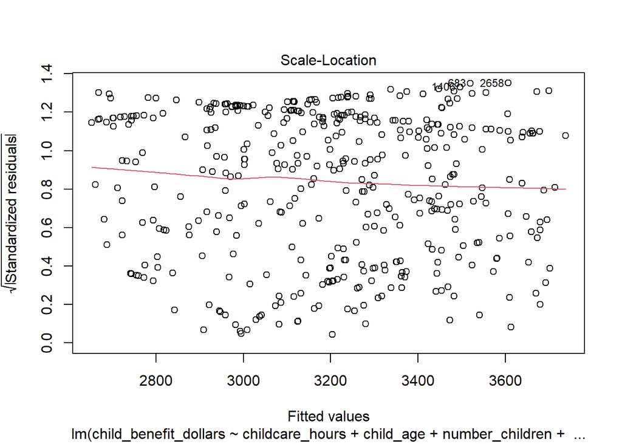

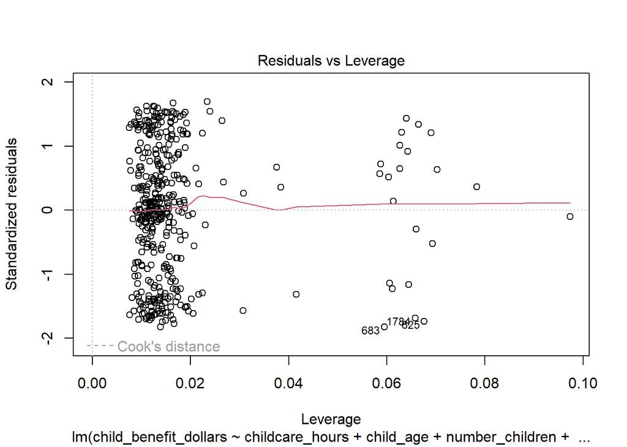

```r
plot(mod)
```

In the Residuals vs Fitted plot, the line is close to being horizontal, but it slightly increases at both ends and slightly decreases in the middle. The points surround the 0 line in a way that suggests equal variance, and there does not seem to be any obvious outliers. This is evidence that this plot does not violate the linearity assumption, and the variables in this model have a linear relationship.

In the Q-Q Residuals plot, a majority of the points closely follow the line along the middle, but the distribution becomes more horizontal at both ends of the line. This shows that most of the residuals are normally distributed, but some residuals fall outside of the normal distribution.

The Scale-Location plot has a mostly horizontal line with a slight negative slope. There are evenly and randomly spread points surrounding the line. This plot seems to display homoscedasticity/equal variance.

In the Residuals vs Leverage plot, the line is mostly horizontal and overlaps the 0 line, and the Cook’s distance lines are barely visible. Most of the points are located between 0 and 0.02 on the x-axis, but several points are located farther along the x-axis. The most influential observations are located at 0.06 on the x-axis, and they are close to -2 on the y-axis where the Cook’s distance line is located.

Based on the four plots, it seems like the model has a decent fit. The does not violate the assumption of equal variance or the linearity assumption. The residuals mostly follow a normal distribution and are evenly spread. Some of the influential variables and outliers could be investigated and transformed or removed to potentially improve the performance of the model.

```r
adj_r2 <- summary(mod)$adj.r.squared
adj_r2
```

```
[1] 0.003496629
```

## Conclusion

The results of this regression model show that people who spend more time caring for their children are not more likely to recommend higher child tax benefits. This does not support the hypothesis that people who spend more time caring for their children on their own are more likely to support a higher child tax credit.

Although the model shows that childcare_hours had a negative coefficient, the value of -$1.08 is too small to use as evidence that people’s support for a larger child tax benefit decreases as the amount of time they spend solely caring for their children increases.

The low adjusted R-squared value shows that the relationship between variables in this model is weak, and other models would be more efficient at explaining the variance in amounts of suggested child tax benefits.

This model showed a significant negative effect for child age at the 0.1 level, which was the only significant effect in this model. In this model, the suggested child tax benefit decreases as the child’s age increases, which could be because families with younger children are in need of more financial support than families with older children.

Future research could further investigate how family characteristics like childcare distribution and ages of children influence support for policies such as a larger child tax benefit.

## References

“American Rescue Plan.” 2021. *The White House*. The United States Government. https://www.whitehouse.gov/american-rescue-plan/.

Batra, Akansha, Kaitlyn Jackson, and Rita Hamad. 2023. “Effects of the 2021 Expanded Child Tax Credit on Adults’ Mental Health: A Quasi-Experimental Study: Study Examines the Effects of the Expanded Child Tax Credit on Mental Health Among Low-Income Adults with Children and Racial and Ethnic Subgroups.” *Health Affairs* 42 (1): 74–82.

Chavez, Laura J, Andreas A Teferra, Rose Hardy, Tansel Yilmazer, and Jennifer Cooper. 2024. “The Effect of the US Child Tax Credit Advance Payments in 2021 on Adolescent Mental Health: Changes in Depression Symptoms and Suicidality.” *Preventive Medicine Reports* 46: 102811.

Chen, Cliff Yung-Chi, Elena Byrne, and Tanya Vélez. 2022. “Impact of the 2020 Pandemic of COVID-19 on Families with School-Aged Children in the United States: Roles of Income Level and Race.” *Journal of Family Issues* 43 (3): 719–40.

López-Santana, Mariely, Lucas Núñez, and Daniel Béland. 2023. “Assessing Public Support for Social Policy in Times of Crisis: Evidence from the Child Tax Credit During the COVID-19 Era in the United States.” *Policy and Society* 42 (4): 526–47.

Pressman, Steven, and Robert Haywood Scott III. 2022. “A Refundable Tax Credit for Children: Its Impact on Poverty, Inequality, and Household Debt.” *Journal of Post Keynesian Economics* 45 (4): 536–57.

Zamarro, Gema, and Marı́a J Prados. 2021. “Gender Differences in Couples’ Division of Childcare, Work and Mental Health During COVID-19.” *Review of Economics of the Household* 19 (1): 11–40.